# All21 K=3 niche transcriptomics: patient-level pseudobulk and robustness audit

Rendered 2026-10-11T20:54:15; report ID 261011205415

**Approved scope.** Frozen Reference18 UMI50 RCTD weights and frozen disease-blind CN1/CN2/CN3 assignments were reused. No RCTD, neighborhood construction, K selection, or niche assignment was rerun.

## 1. Question and statistical unit

The analysis asks whether the same shared niche has a different transcriptional state among HC, IPF and SSc-ILD. Raw integer counts were aggregated into 21 patients × 3 niches (63 libraries). Patients—not bins—are the biological replicates. Separate edgeR models used `~ chip + disease`. The prespecified sensitivity excluded 2 libraries containing fewer than 20 member bins.

## 2. Fixed biological programs

**Result:** 0/144 program-by-niche-by-contrast tests passed global BH-FDR < 0.05. Thus the eight fixed programs do not support a broad disease-associated program shift at this resolution.

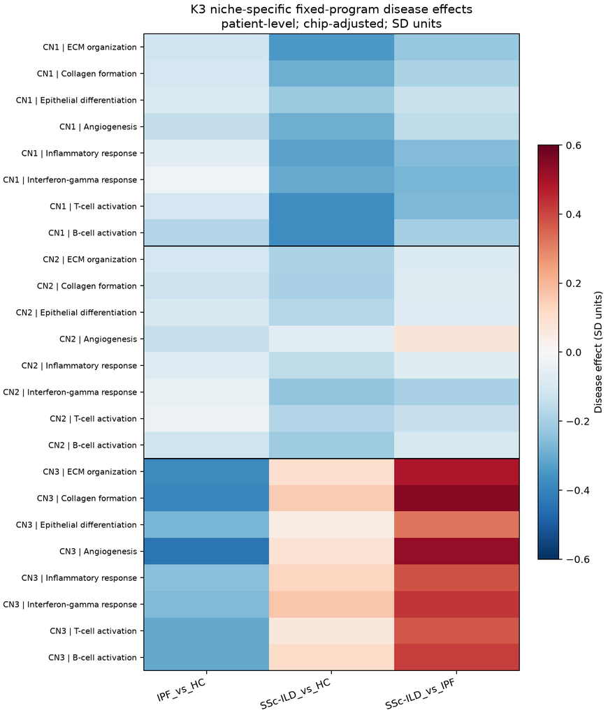

Figure 1. Patient-level effects for eight prespecified gene programs.

## 3. Exploratory niche-specific differential expression

The primary models identified gene-level candidates, followed by a predeclared low-bin sensitivity analysis. Requiring direction agreement, sensitivity FDR < 0.05 and |log2FC| ≥ 0.5 retained 21 gene-by-contrast rows. These are candidates for auditing, not 21 independently confirmed discoveries.

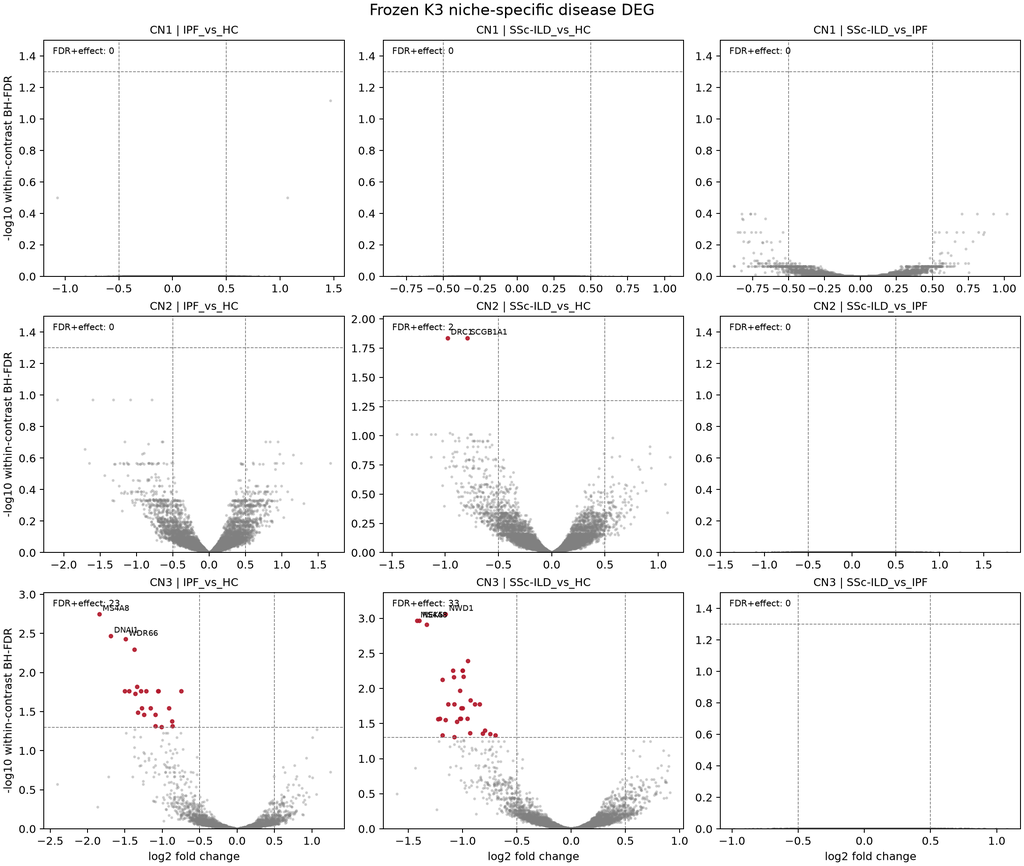

Figure 2. Niche-specific edgeR results for all disease contrasts.

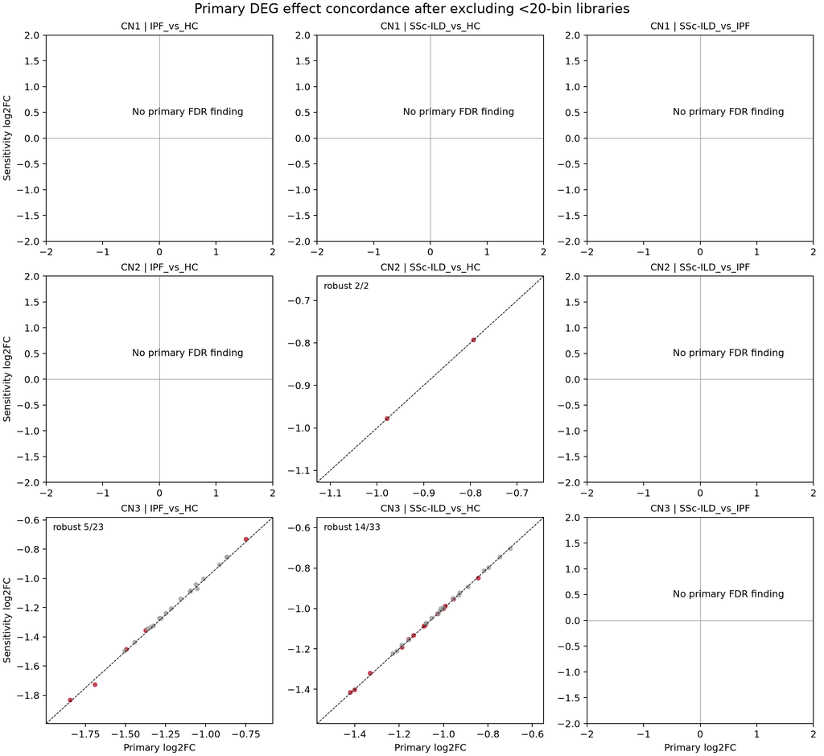

Figure 3. Primary effects versus the low-bin exclusion sensitivity effects.

| niche | comparison | primary_supported_genes | same_direction_genes | sensitivity_supported_genes | robust_genes |
| --- | --- | --- | --- | --- | --- |
| CN1 | IPF_vs_HC | 0 | 0 | 0 | 0 |
| CN1 | SSc-ILD_vs_HC | 0 | 0 | 0 | 0 |
| CN1 | SSc-ILD_vs_IPF | 0 | 0 | 0 | 0 |
| CN2 | IPF_vs_HC | 0 | 0 | 0 | 0 |
| CN2 | SSc-ILD_vs_HC | 2 | 2 | 2 | 2 |
| CN2 | SSc-ILD_vs_IPF | 0 | 0 | 0 | 0 |
| CN3 | IPF_vs_HC | 23 | 23 | 5 | 5 |
| CN3 | SSc-ILD_vs_HC | 33 | 33 | 14 | 14 |
| CN3 | SSc-ILD_vs_IPF | 0 | 0 | 0 | 0 |

## 4. Is the signal only altered Reference18 composition?

No Reference18 state × niche × disease comparison passed global FDR (0/324). All 21/21 audited gene-by-contrast rows retained nominal P < 0.05 after separately adjusting for the ciliated-epithelial fraction. This argues against broad ciliated composition as the sole explanation, but cannot exclude finer subtype shifts or state/composition coupling below Reference18 resolution.

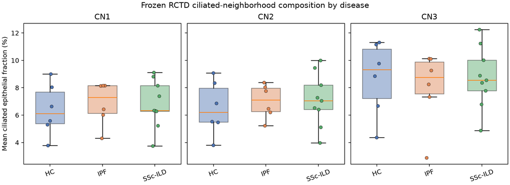

Figure 4. Ciliated-epithelial composition across disease groups within each niche.

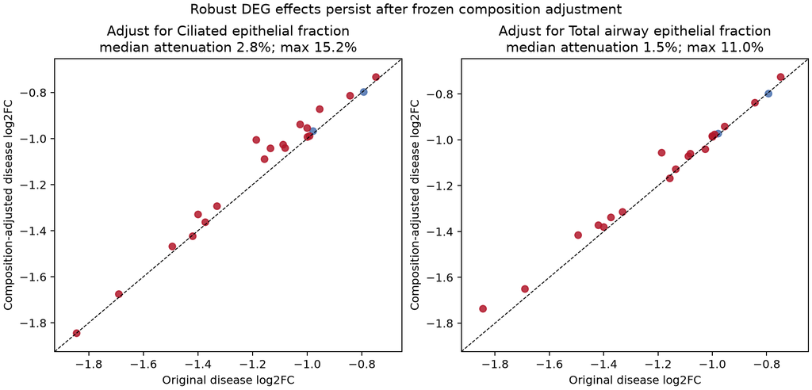

Figure 5. Original and Reference18 composition-adjusted disease effects.

## 5. Patient, chip, and technical robustness

21/21 rows preserved direction in every leave-one-patient-out refit; 14/21 preserved direction in all three chips. Independent adjustments for niche bin count, median raw UMI, median detected genes, and median mitochondrial fraction were used as diagnostics. Because these covariates may also carry genuine injury biology, attenuation indicates uncertainty rather than proving artifact.

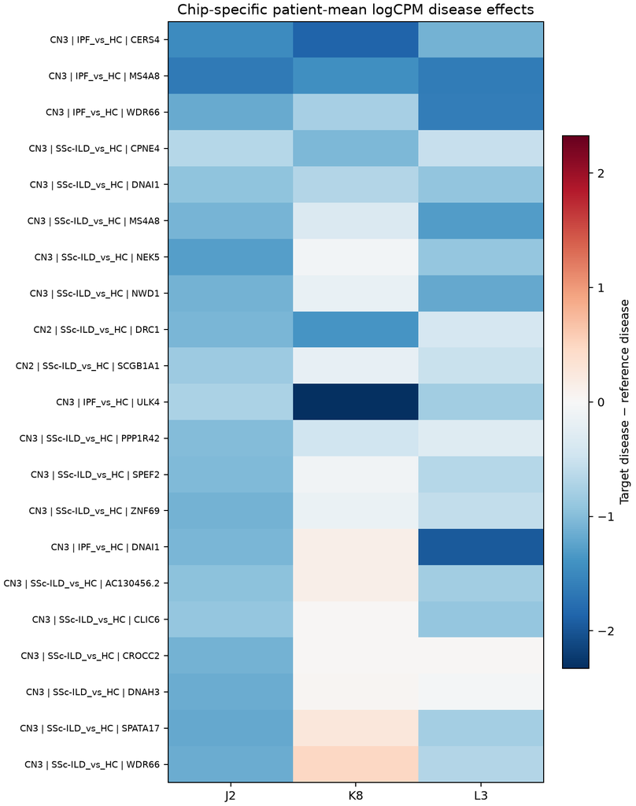

Figure 6. Disease effects estimated separately in J2, K8, and L3.

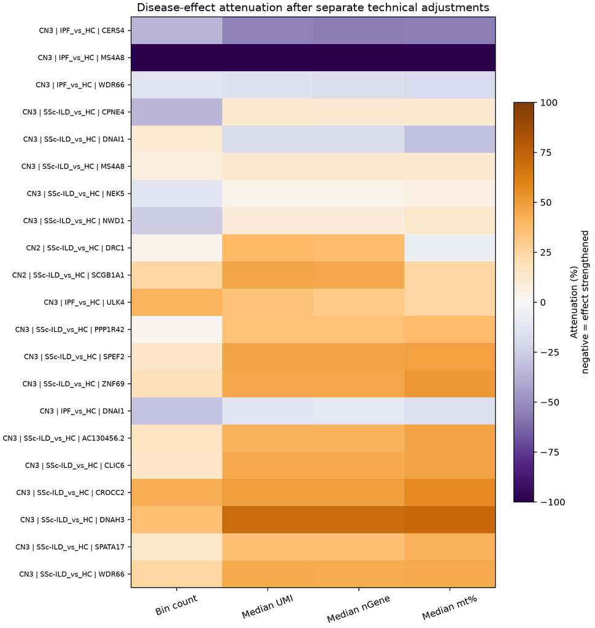

Figure 7. Effect attenuation after separate technical-covariate adjustments.

| evidence_tier | gene_contrast_rows |
| --- | --- |
| Tier_A_cross_chip_and_technical_stable | 8 |
| Tier_C_patient_stable_but_chip_heterogeneous | 7 |
| Tier_B_cross_chip_direction_stable_but_qc_attenuated | 6 |

## 6. Highest-confidence subset

**Tier A:** 8 gene-by-contrast rows (7 unique genes) pass all prespecified direction and attenuation checks. Every Tier-A row occurs in CN3 and represents lower expression in disease than HC. This is a within-CN3 state signal—not a new niche, a cell-type abundance result, or proof of causality.

| niche | comparison | gene_symbol | same_direction_chips | same_direction_lopo | maximum_technical_attenuation | evidence_tier |
| --- | --- | --- | --- | --- | --- | --- |
| CN3 | IPF_vs_HC | CERS4 | 3 | 21 | -0.359 | Tier_A_cross_chip_and_technical_stable |
| CN3 | IPF_vs_HC | WDR66 | 3 | 21 | -0.139 | Tier_A_cross_chip_and_technical_stable |
| CN3 | IPF_vs_HC | MS4A8 | 3 | 21 | -1.126 | Tier_A_cross_chip_and_technical_stable |
| CN3 | SSc-ILD_vs_HC | DNAI1 | 3 | 21 | 0.103 | Tier_A_cross_chip_and_technical_stable |
| CN3 | SSc-ILD_vs_HC | MS4A8 | 3 | 21 | 0.125 | Tier_A_cross_chip_and_technical_stable |
| CN3 | SSc-ILD_vs_HC | NWD1 | 3 | 21 | 0.129 | Tier_A_cross_chip_and_technical_stable |
| CN3 | SSc-ILD_vs_HC | CPNE4 | 3 | 21 | 0.124 | Tier_A_cross_chip_and_technical_stable |
| CN3 | SSc-ILD_vs_HC | NEK5 | 3 | 21 | 0.061 | Tier_A_cross_chip_and_technical_stable |

## 7. Direct unsmoothed spatial checks

Maps use direct raw Bin50 detections without smoothing: grey marks evaluable tissue, blue marks the target niche, and magma-colored points mark bins with detected transcript. Sparse single-bin detection is expected; inference remains patient-level pseudobulk.

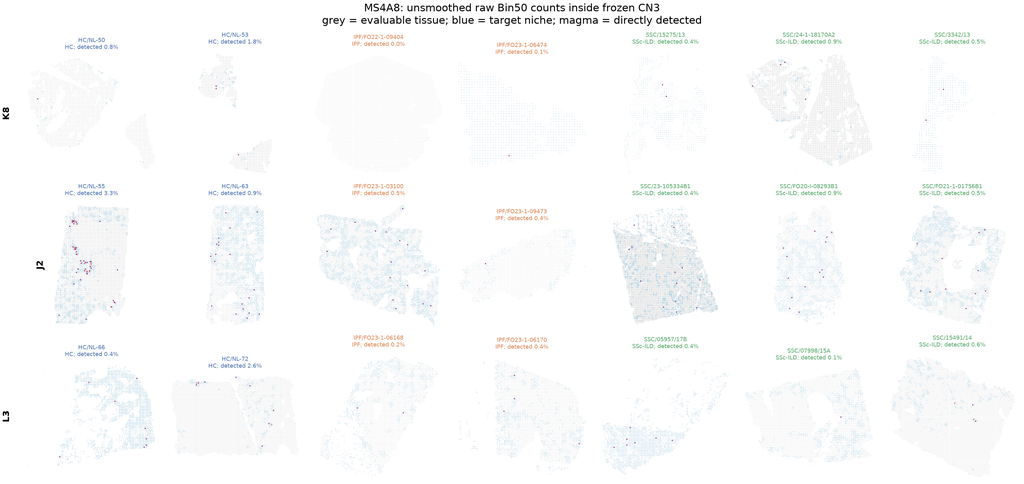

Figure 8. Unsmoothed MS4A8 counts in CN3 across patients.

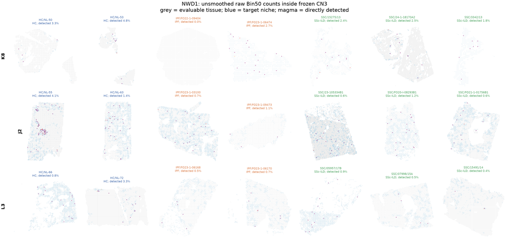

Figure 9. Unsmoothed NWD1 counts in CN3 across patients.

## 8. Interpretation and limits

- The original unbiased K=3 niches remain descriptive mixed-tissue neighborhoods; this analysis tests transcriptional state within them.
- The strongest reproducible signal is CN3 disease-versus-HC downregulation, represented by the Tier-A set.
- CN2 SCGB1A1 and DRC1 are cross-chip and patient-direction stable but QC-attenuated, so they remain provisional.
- No fixed program passed global FDR, and no broad Reference18 composition change explains the candidate set.
- Post-selection diagnostics refine confidence but are not independent replication. Biological naming requires unbiased ranked-pathway analysis and orthogonal marker/anatomical validation.

## 9. Validation and provenance

| section | check | observed | expected | status |
| --- | --- | --- | --- | --- |
| pseudobulk preparation | evaluable_k3_bins | 126199 | 126199 | PASS |
| pseudobulk preparation | patients | 21 | 21 | PASS |
| pseudobulk preparation | patient_niche_libraries | 63 | 63 | PASS |
| pseudobulk preparation | genes | 27618 | 27618 | PASS |
| pseudobulk preparation | negative_count_values | 0 | 0 | PASS |
| pseudobulk preparation | noninteger_count_values | 0 | 0 | PASS |
| pseudobulk preparation | total_counts_reconcile_h5ad_common_raw | 77460973 | 77460973 | PASS |
| pseudobulk preparation | rctd_nUMI_total_for_context_only | 68074082 | not expected to equal common-gene raw H5AD total | INFO |
| pseudobulk preparation | low_coverage_patient_niche_lt20_bins | 2 | reported_not_hidden | PASS |
| edgeR models | primary_models | 3 | 3 | PASS |
| edgeR models | sensitivity_models | 3 | 3 | PASS |
| edgeR models | primary_patient_count_each_niche | 21,21,21 | 21,21,21 | PASS |
| edgeR models | design_full_rank | TRUE | TRUE | PASS |
| edgeR models | program_count | 8 | 8 | PASS |
| edgeR models | count_library_reconciliation | TRUE | TRUE | PASS |
| edgeR models | seed_fixed | 20261011 | 20261011 | PASS |
| composition audit | patient_niche_rows | 63 | 63 | PASS |
| composition audit | robust_gene_contrast_rows | 21 | 21 | PASS |
| composition audit | composition_states | 18 | 18 | PASS |
| composition audit | composition_models_full_rank | 1 | 1 | PASS |
| composition audit | adjusted_models_full_rank | 1 | 1 | PASS |
| composition audit | analyses | 2 | 2 | PASS |
| composition audit | composition_covariates | 2 | 2 | PASS |
| technical/patient audit | robust_gene_contrast_rows | 21 | 21 | PASS |
| technical/patient audit | technical_models_per_row | 5 | 5 | PASS |
| technical/patient audit | chip_effects_per_row | 3 | 3 | PASS |
| technical/patient audit | lopo_effects_per_row | 21 | 21 | PASS |
| technical/patient audit | all_model_fits_complete | 1 | 1 | PASS |

### Input fingerprints

| artifact | path | sha256 |
| --- | --- | --- |
| input_manifest | D:\Lung ST\codex agent\stereo_seq\stereo_seq\results\reanalysis\ALL21_K3_NICHE_PSEUDOBULK_DEG_20261011_201008\00_INPUT_MANIFEST.tsv | 2a6151b6e0335ed4245dd1a3a49517c5c10dba74ae00862e9f637649a862b2d0 |
| sample_metadata | D:\Lung ST\codex agent\stereo_seq\stereo_seq\results\reanalysis\ALL21_K3_NICHE_PSEUDOBULK_DEG_20261011_201008\01_PSEUDOBULK_SAMPLE_METADATA.tsv | cf06e7c03dcb60de0b3f8d01d012f23e0e5bb1aed50448ec4a95899e9d7103e6 |
| preparation_validation | D:\Lung ST\codex agent\stereo_seq\stereo_seq\results\reanalysis\ALL21_K3_NICHE_PSEUDOBULK_DEG_20261011_201008\04_PREPARATION_VALIDATION.tsv | 4cc3a4952615d1e07b0dc84450b52280de838e92f1b0e369fdb97185ca62995c |
| program_tests | D:\Lung ST\codex agent\stereo_seq\stereo_seq\results\reanalysis\ALL21_K3_NICHE_PSEUDOBULK_DEG_20261011_201008\09_PROGRAM_DISEASE_TESTS.tsv | 234ba0d2a56256f4740b7929a1b24bfde1c54c7103165431ef5fb7ee7f0f4eb0 |
| deg_summary | D:\Lung ST\codex agent\stereo_seq\stereo_seq\results\reanalysis\ALL21_K3_NICHE_PSEUDOBULK_DEG_20261011_201008\12_DEG_SUMMARY.tsv | 3abe4528bfabb74ed72d9e7354aa5d8c28fb3173d39eb50e90f52939af9f6379 |
| model_validation | D:\Lung ST\codex agent\stereo_seq\stereo_seq\results\reanalysis\ALL21_K3_NICHE_PSEUDOBULK_DEG_20261011_201008\14_FINAL_VALIDATION.tsv | b88b4b45541c185f6150e0795b214bb9f4909d3418d6acd6df7ffa0628f4c7e6 |
| robustness | D:\Lung ST\codex agent\stereo_seq\stereo_seq\results\reanalysis\ALL21_K3_NICHE_PSEUDOBULK_DEG_20261011_201008\17_DEG_ROBUSTNESS_SUMMARY.tsv | fb65f22e8033e510d691b7f1d0dd664cbacac63822c71d4abb7bdb028cbc97b1 |
| composition_tests | D:\Lung ST\codex agent\stereo_seq\stereo_seq\results\reanalysis\ALL21_K3_NICHE_PSEUDOBULK_DEG_20261011_201008\22_RCTD_COMPOSITION_DISEASE_TESTS.tsv | ff4de9be421e4b847cf65274c20b38c5c528a0f8267444941ed02d54ade3c750 |
| composition_adjusted | D:\Lung ST\codex agent\stereo_seq\stereo_seq\results\reanalysis\ALL21_K3_NICHE_PSEUDOBULK_DEG_20261011_201008\23_COMPOSITION_ADJUSTED_ROBUST_DEG.tsv | 263fb26adff7c8b2779c7ad7c18484c889d0e889e39f63bc201aa5d3c1c4fc2d |
| composition_summary | D:\Lung ST\codex agent\stereo_seq\stereo_seq\results\reanalysis\ALL21_K3_NICHE_PSEUDOBULK_DEG_20261011_201008\27_COMPOSITION_VS_STATE_SUMMARY.tsv | dba63c2111a243bd290a83ada1f344480b339e8d68d106fd117802177dd55002 |
| composition_validation | D:\Lung ST\codex agent\stereo_seq\stereo_seq\results\reanalysis\ALL21_K3_NICHE_PSEUDOBULK_DEG_20261011_201008\28_COMPOSITION_VS_STATE_VALIDATION.tsv | fbd2ad5ed6bbfd247c6a7104c3fe8399b558f33c27f76d1d658521437a3a6d1b |
| technical_summary | D:\Lung ST\codex agent\stereo_seq\stereo_seq\results\reanalysis\ALL21_K3_NICHE_PSEUDOBULK_DEG_20261011_201008\36_TECHNICAL_PATIENT_CONSISTENCY_SUMMARY.tsv | 1f085db9ddbd4a6dc05bf31acd5aaa0af5ced753b0f32df1bc2b5e2510d5a71d |
| technical_validation | D:\Lung ST\codex agent\stereo_seq\stereo_seq\results\reanalysis\ALL21_K3_NICHE_PSEUDOBULK_DEG_20261011_201008\37_TECHNICAL_PATIENT_CONSISTENCY_VALIDATION.tsv | e7a4b1230475b88c07b9b72d8fbded4a9410f5a92820eb47536fada1447dc89f |
| evidence_tiers | D:\Lung ST\codex agent\stereo_seq\stereo_seq\results\reanalysis\ALL21_K3_NICHE_PSEUDOBULK_DEG_20261011_201008\38_TECHNICAL_EVIDENCE_TIER_ASSIGNMENT.tsv | c8729c993ac2081e22a0289f88fde0b13e90bdb15f3a8ec60ff9ff1f78b7746b |
| program_figure | D:\Lung ST\codex agent\stereo_seq\stereo_seq\results\reanalysis\ALL21_K3_NICHE_PSEUDOBULK_DEG_20261011_201008\figures\FIG01_PROGRAM_DISEASE_EFFECT_HEATMAP.png | a82c22f49a81aa75da26d35e59990c6652a69c57aaafe65972d006629426e30f |
| volcano_figure | D:\Lung ST\codex agent\stereo_seq\stereo_seq\results\reanalysis\ALL21_K3_NICHE_PSEUDOBULK_DEG_20261011_201008\figures\FIG02_NICHE_DISEASE_DEG_VOLCANO.png | 30229b4d5e5a51c5b4fb6495ae9744bbf88742575ddb308b374fc18955ef51f1 |
| sensitivity_figure | D:\Lung ST\codex agent\stereo_seq\stereo_seq\results\reanalysis\ALL21_K3_NICHE_PSEUDOBULK_DEG_20261011_201008\figures\FIG03_PRIMARY_VS_LOW_BIN_EXCLUSION_DEG.png | 5814bbe1231c0386f17c1818e5fec21a62f4d0da319c96f3b5f359379f2453b7 |
| composition_figure | D:\Lung ST\codex agent\stereo_seq\stereo_seq\results\reanalysis\ALL21_K3_NICHE_PSEUDOBULK_DEG_20261011_201008\figures\FIG04_CILIATED_COMPOSITION_BY_DISEASE.png | 98852443e2f40b842e1cafcc8b32859d7176e2b2cb7d8664800f0f8b7c2060e6 |
| adjusted_figure | D:\Lung ST\codex agent\stereo_seq\stereo_seq\results\reanalysis\ALL21_K3_NICHE_PSEUDOBULK_DEG_20261011_201008\figures\FIG05_ORIGINAL_VS_COMPOSITION_ADJUSTED_DEG.png | 0bb4af6f423dc5e7a2bea4a6fa055b5c2fdc8e11330947c2ef6e5cba494bfb0d |
| chip_figure | D:\Lung ST\codex agent\stereo_seq\stereo_seq\results\reanalysis\ALL21_K3_NICHE_PSEUDOBULK_DEG_20261011_201008\figures\FIG06_CHIP_SPECIFIC_GENE_EFFECT_HEATMAP.png | b2d190754a28773ddaf40beeb0719283664acb54b2deb8d4d78086e637d4bc60 |
| attenuation_figure | D:\Lung ST\codex agent\stereo_seq\stereo_seq\results\reanalysis\ALL21_K3_NICHE_PSEUDOBULK_DEG_20261011_201008\figures\FIG07_TECHNICAL_COVARIATE_ATTENUATION_HEATMAP.png | 670533b722d999947a6f3002a7627c27c0ee788100940c74be5d4ed7f54c45e9 |
| spatial_ms4a8 | D:\Lung ST\codex agent\stereo_seq\stereo_seq\results\reanalysis\ALL21_K3_NICHE_PSEUDOBULK_DEG_20261011_201008\figures\FIG08_SPATIAL_MS4A8_CN3.png | 95b4f6d7246c00ac1c7a3e10a24ff0aa02ec50d475e967122ca283ba8ddc66f9 |
| spatial_nwd1 | D:\Lung ST\codex agent\stereo_seq\stereo_seq\results\reanalysis\ALL21_K3_NICHE_PSEUDOBULK_DEG_20261011_201008\figures\FIG08_SPATIAL_NWD1_CN3.png | 2b25bffdbb463cacd7cfa9abfd911fd1270bd7ed0272bb7f84cfafa288afc159 |
| session_info | D:\Lung ST\codex agent\stereo_seq\stereo_seq\results\reanalysis\ALL21_K3_NICHE_PSEUDOBULK_DEG_20261011_201008\SESSION_INFO.txt | 2c1d213e0c3f43c30058a9d79012febc9f157e552ffafb57695db481598cbb91 |
| composition_session_info | D:\Lung ST\codex agent\stereo_seq\stereo_seq\results\reanalysis\ALL21_K3_NICHE_PSEUDOBULK_DEG_20261011_201008\SESSION_INFO_COMPOSITION_VS_STATE.txt | 2c1d213e0c3f43c30058a9d79012febc9f157e552ffafb57695db481598cbb91 |

### Session information

```
R version 4.5.3 (2026-03-11)
Platform: x86_64-conda-linux-gnu
Running under: Ubuntu 24.04.4 LTS

Matrix products: default
BLAS/LAPACK: /mnt/d/Lung ST/codex agent/stereo_seq/stereo_seq/envs/r_edger_k3/lib/libopenblasp-r0.3.34.so;  LAPACK version 3.12.0

locale:
 [1] LC_CTYPE=C.UTF-8       LC_NUMERIC=C           LC_TIME=C.UTF-8
 [4] LC_COLLATE=C.UTF-8     LC_MONETARY=C.UTF-8    LC_MESSAGES=C.UTF-8
 [7] LC_PAPER=C.UTF-8       LC_NAME=C              LC_ADDRESS=C
[10] LC_TELEPHONE=C         LC_MEASUREMENT=C.UTF-8 LC_IDENTIFICATION=C

time zone: Europe/Berlin
tzcode source: system (glibc)

attached base packages:
[1] stats     graphics  grDevices utils     datasets  methods   base

other attached packages:
[1] Matrix_1.7-6 edgeR_4.10.5 limma_3.68.5

loaded via a namespace (and not attached):
[1] compiler_4.5.3  splines_4.5.3   grid_4.5.3      locfit_1.5-9.12
[5] lattice_0.23-1  statmod_1.5.2
```

```
R version 4.5.3 (2026-03-11)
Platform: x86_64-conda-linux-gnu
Running under: Ubuntu 24.04.4 LTS

Matrix products: default
BLAS/LAPACK: /mnt/d/Lung ST/codex agent/stereo_seq/stereo_seq/envs/r_edger_k3/lib/libopenblasp-r0.3.34.so;  LAPACK version 3.12.0

locale:
 [1] LC_CTYPE=C.UTF-8       LC_NUMERIC=C           LC_TIME=C.UTF-8
 [4] LC_COLLATE=C.UTF-8     LC_MONETARY=C.UTF-8    LC_MESSAGES=C.UTF-8
 [7] LC_PAPER=C.UTF-8       LC_NAME=C              LC_ADDRESS=C
[10] LC_TELEPHONE=C         LC_MEASUREMENT=C.UTF-8 LC_IDENTIFICATION=C

time zone: Europe/Berlin
tzcode source: system (glibc)

attached base packages:
[1] stats     graphics  grDevices utils     datasets  methods   base

other attached packages:
[1] Matrix_1.7-6 edgeR_4.10.5 limma_3.68.5

loaded via a namespace (and not attached):
[1] compiler_4.5.3  splines_4.5.3   grid_4.5.3      locfit_1.5-9.12
[5] lattice_0.23-1  statmod_1.5.2
```

Report renderer: Python 3.12.14 (main, Aug 25 2026, 14:01:42) [MSC v.1944 64 bit (AMD64)]  
Windows-11-10.0.26200-SP0  
numpy 2.4.6; pandas 3.0.5